# Lab4

1. Estimate the letter occurrence probabilities of all 26 letters in English by measuring a paragraph of English text from wikipedia. (hint use strsplit() to split a paragraph into individual letters) (1 point).

```r
wikipedia <- "The bee-eaters are near passerine birds of the family Meropidae, containing three genera and twenty-seven species. Most species are found in Africa and Asia, with a few in southern Europe, Australia, and New Guinea. They are characterised by richly coloured plumage and slender bodies, and usually by elongated central tail feathers. All have long down-turned bills and medium to long wings, which may be pointed or round. They predominantly eat flying insects, caught on the wing from an open perch. Most bee-eaters are gregarious, forming colonies and nesting in burrows. The eggs are white, with typically five to the clutch. Most species are monogamous, and both parents care for the young, sometimes with assistance from related birds in the colony. Bee-eaters may be killed by raptors; their nests are raided by rodents and snakes, and they can carry various parasites. Some species are adversely affected by human activity or habitat loss, but none are threatened."

wikipedia_letters <- unlist(strsplit(wikipedia, split = ""))
lower_case <- tolower(wikipedia_letters)
letter_counts <- table(lower_case)
letter_counts <- data.frame(letter_counts)

library(dplyr)
final <- letter_counts %>%
  filter(lower_case %in% letters == TRUE)

total_letters <- sum(final$Freq)

final <- final %>%
  mutate(probabilities = Freq/total_letters)

knitr::kable(final)
```

| lower_case | Freq | probabilities |
| --- | --- | --- |
| a | 76 | 0.0964467 |
| b | 18 | 0.0228426 |
| c | 26 | 0.0329949 |
| d | 33 | 0.0418782 |
| e | 109 | 0.1383249 |
| f | 14 | 0.0177665 |
| g | 19 | 0.0241117 |
| h | 30 | 0.0380711 |
| i | 52 | 0.0659898 |
| k | 2 | 0.0025381 |
| l | 29 | 0.0368020 |
| m | 20 | 0.0253807 |
| n | 61 | 0.0774112 |
| o | 47 | 0.0596447 |
| p | 16 | 0.0203046 |
| r | 58 | 0.0736041 |
| s | 56 | 0.0710660 |
| t | 60 | 0.0761421 |
| u | 21 | 0.0266497 |
| v | 6 | 0.0076142 |
| w | 12 | 0.0152284 |
| y | 23 | 0.0291878 |

2. Generate “random” strings of letters that are sampled from a distribution where letter occurrence probability is the same as natural English. Use the probabilities for each letter from this wikipedia article, or use your own estimates from the previous question (2 points).

```r
my_letters <- sample(final$lower_case,50*5,replace=TRUE, prob = final$probabilities)

# turn the vector into a matrix with 5 columns
my_strings <- matrix(my_letters, ncol=5)

# each row is a word, need to collapse the column to create a string
paste(my_strings[1,], collapse="")
```

```
## [1] "eeeca"
```

[output not shown]

```r
# loop to collapse all of the rows into words
random_strings <-c()
for(i in 1:dim(my_strings)[1]){
  random_strings[i] <- paste(my_strings[i,], collapse="")
}

random_strings
```

```
##  [1] "eeeca" "tiill" "deett" "rtnra" "tpbey" "peear" "nfocr" "tbbai" "lieaf"
## [10] "ionbn" "aldip" "eialt" "ellia" "oottd" "uuaao" "wyept" "iabtt" "oglat"
## [19] "doneo" "esnrb" "rnhac" "eotnn" "odege" "fyrsa" "eifac" "caeby" "olutt"
## [28] "egeeg" "dccer" "twaib" "uedal" "nsaei" "ibiam" "ilesd" "utatt" "liari"
## [37] "wenao" "sidee" "edpno" "nsaeh" "hmstu" "deneo" "maemh" "atyre" "oeyso"
## [46] "tyrsc" "husip" "nhade" "tieed" "eufaa"
```

3. Generate a random walk of 10,000 steps. In a random walk, you are simulating the process of randomly taking a step up or down, as if you are on an infinite staircase. At each step you flip a coin. If you get heads you go up one step, if you get tails you go down one step. Start on step 0, then simulate a random walk for 10,000 steps. Your vector should preserve the step number for each step. For example, if the the first three steps were all heads, then the vector would begin with 0,1,2,3, which indicates a single step up each time. Plot the first 1,000 steps. (1 point)

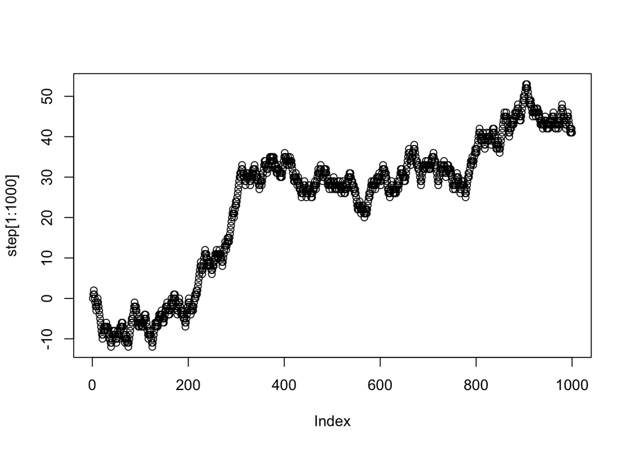

```r
step <- c(0)
for(i in 1:10000){
  coin_flip <- sample(c(1,-1),1)
  step[i+1] <- step[i]+coin_flip
}

plot(step[1:1000])
```

4. What was the most positive and most negative step reached out of 10,000? (1 point)

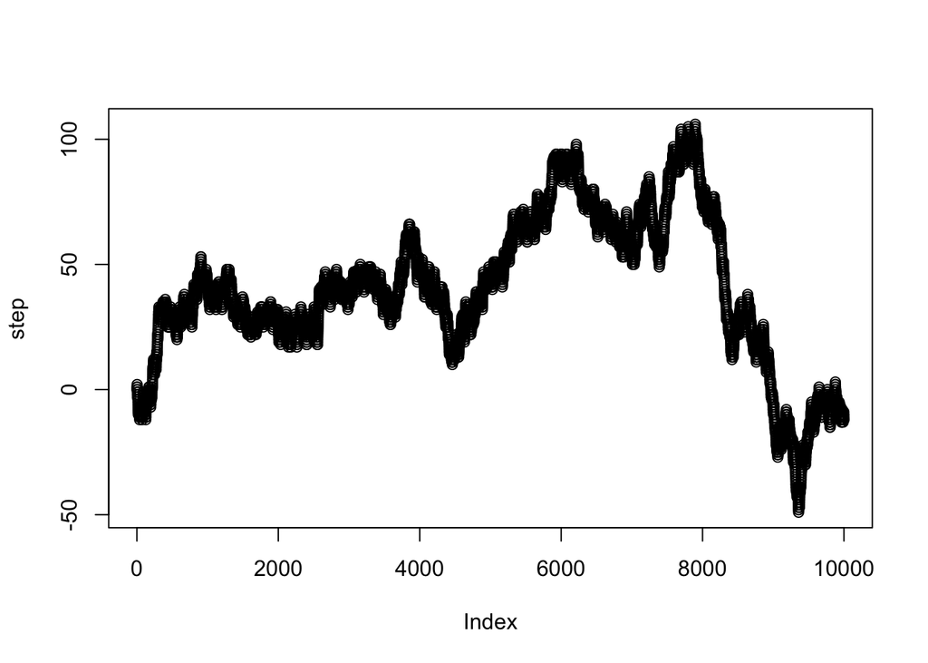

```r
plot(step)
```

```r
max(step)
```

```
## [1] 106
```

```r
min(step)
```

```
## [1] -49
```

5. What was the longest run of steps where all steps were positive numbers. For example, in the sequence: 1,2,3,2,1,0,-1,-2,-1,-2,-1,0,1,2,3; the answer is 5 because the first five values were all positive, and this was the longest sequence of positive values. (1 point).

```r
logical_step <- sign(step)

sequence <- c()
counter <- 0
for(i in 1:length(logical_step)){
  if(logical_step[i] == 0){
    sequence <- c(sequence,counter)
      counter <- 0
  } else {
    counter <- counter+logical_step[i]
  }
}

max(sequence)
```

```
## [1] 8751
```

```r
min(sequence)
```

```
## [1] -679
```